# Info8000 Assignment 3

Description: Exploratory visualization of survey results

Questions:

Q1. Where are the respondents? This snippet reads a shapefile containing the data points, translates it to a dataframe, and plots the points on a Google map of the study area.

[figure not shown]

```r
#maps
library(maptools)
library(ggmap)
#read shp
pts <- readShapePoints("/Volumes/SANDISK/CoastSurvey/Geo/sgeoCh_wgs.shp")
#load basemap
mapImage <- get_map(location = c(lon = -81.09, lat = 32.08),
                    maptype = "terrain",
                    source = "google",
                    zoom = 10)
#convert shp to ggplot-friendly data frame
pts_fr <- data.frame(pts)
#plot points on map
ggmap(mapImage) +
  geom_point(data = pts_fr, aes(x = long, y = lat))
```

Q2. What is the distribution of demographic characteristics of the respondents? Income, Ethnicity, and Education variables visualized as bar graphs:

```r
library(tidyverse)
```

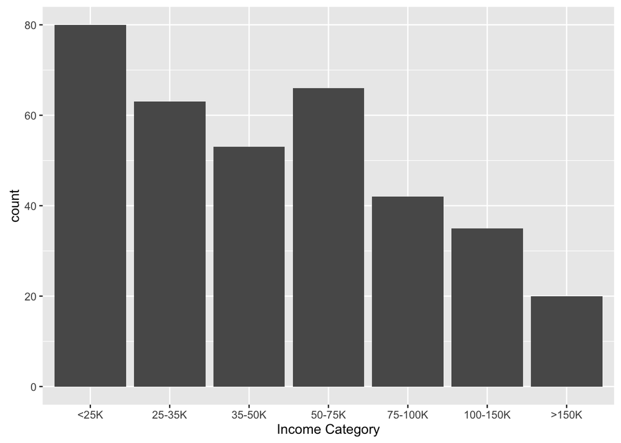

```r
#sgeo <- read.csv("~/Desktop/sgeoTable.csv")
sgeo <- read.csv("~/Desktop/sgeoTable.csv")
a <- ggplot(data = sgeo)

a +
  geom_bar(mapping = aes(x = as.factor(Hincome))) +
    scale_x_discrete(breaks = c(1:7),
                     labels = c("<25K","25-35K","35-50K","50-75K","75-100K","100-150K",">150K")) +
  labs(x = "Income Category")
```

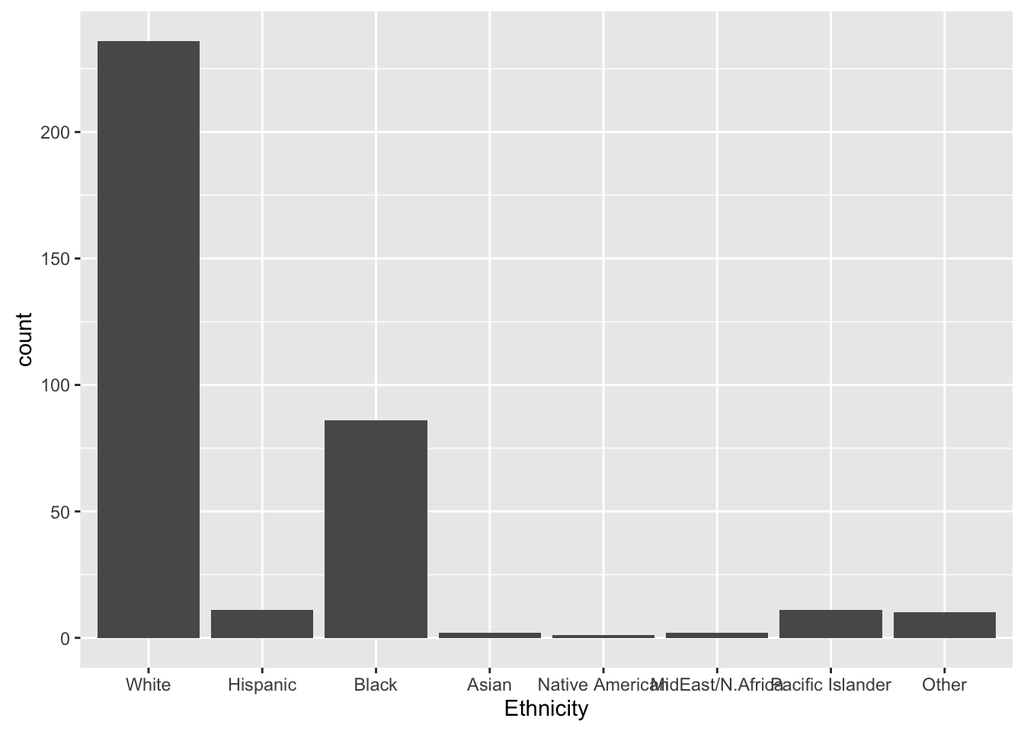

```r
a +
  geom_bar(mapping = aes(x = as.factor(Ethnicity))) +
    scale_x_discrete(breaks = c(1:8),
                  labels = c("White","Hispanic","Black","Asian","Native American",
                                "MidEast/N.Africa","Pacific Islander","Other")) +
  labs(x = "Ethnicity")
```

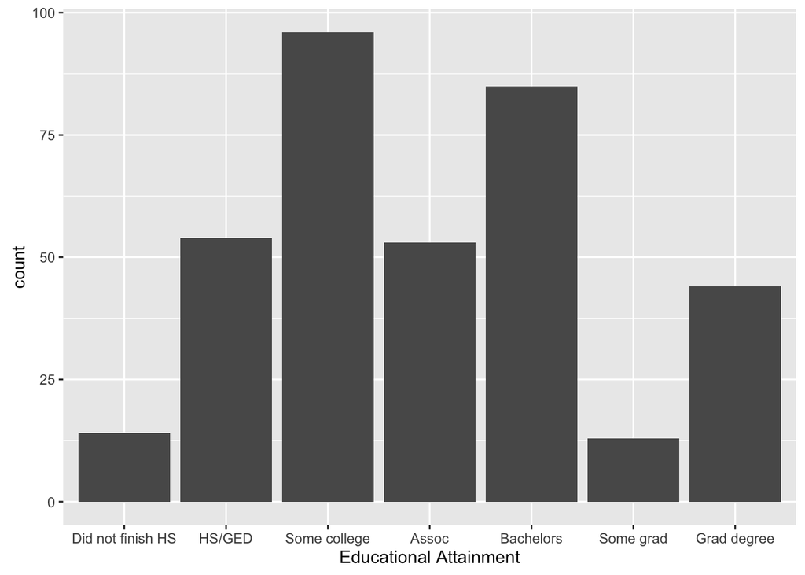

```r
a +
  geom_bar(mapping = aes(x = as.factor(Education))) +
  scale_x_discrete(breaks = c(1:7),
                   labels = c("Did not finish HS","HS/GED","Some college","Assoc","Bachelors","Some grad","Grad degree")) +
  labs(x = "Educational Attainment")
```

Before beginning analysis of the responses, it is helpful to assess the demographic makeup of the participants. Income is bimodally distributed, with many respondents falling into low and middle income categories, as expected. Like the study area as a whole, the sample is majority white with a significant African American minority and a smaller Hispanic minority. Other ethnic identiteis were not well represented. Finally, the educational makeup of the sample is fairly diverse; many respondents have post-high school education.

Q3. Do income, race, or ethnicity relate to how respondents perceive their ability to recover from storms? Less educated and lower income individuals, and members of minority communities are theorized to be less able to recover from the impacts of severe storms. These graphs break down respondents perceived ability to recover from storm damage based on these variables. The results are represented as stacked bar graphs and as boxplots. Higher values indicate greater ability to recover as indicated on the survey.

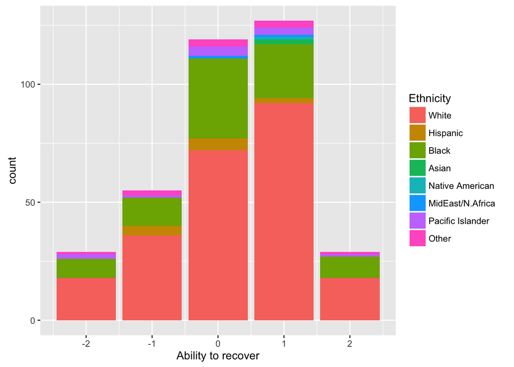

```r
  #by ethnicity
ggplot(sgeo, aes(PCNoRecov))+
  geom_bar(aes(fill = as.factor(Ethnicity))) +
  scale_fill_discrete(name = "Ethnicity", breaks = c(1:8),
                      labels = c("White","Hispanic","Black","Asian","Native American",
                                 "MidEast/N.Africa","Pacific Islander","Other")) +
  labs(x = "Ability to recover")
```

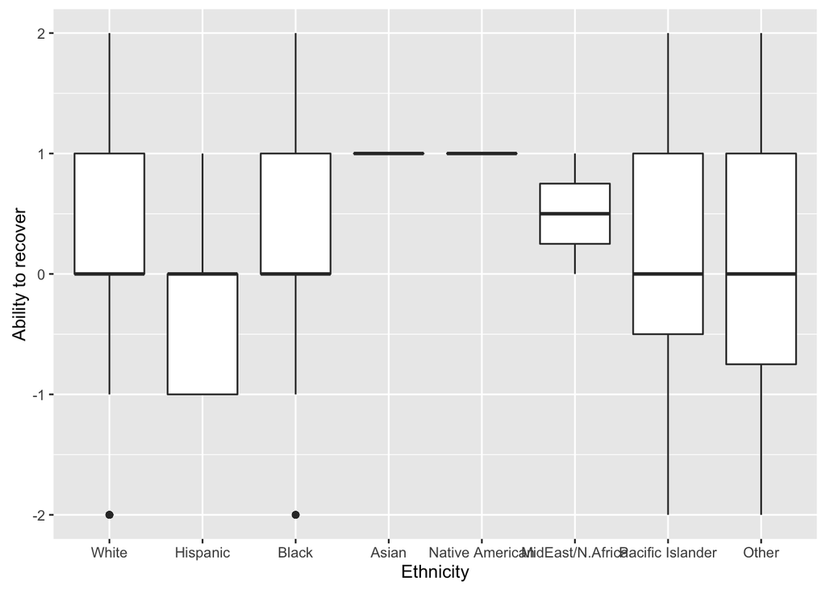

```r
a +
  geom_boxplot(mapping = aes(x = as.factor(Ethnicity),y = PCNoRecov))+
  scale_x_discrete(breaks = c(1:8),
                   labels = c("White","Hispanic","Black","Asian","Native American",
                              "MidEast/N.Africa","Pacific Islander","Other"))+
  labs(x = "Ethnicity",y = "Ability to recover")
```

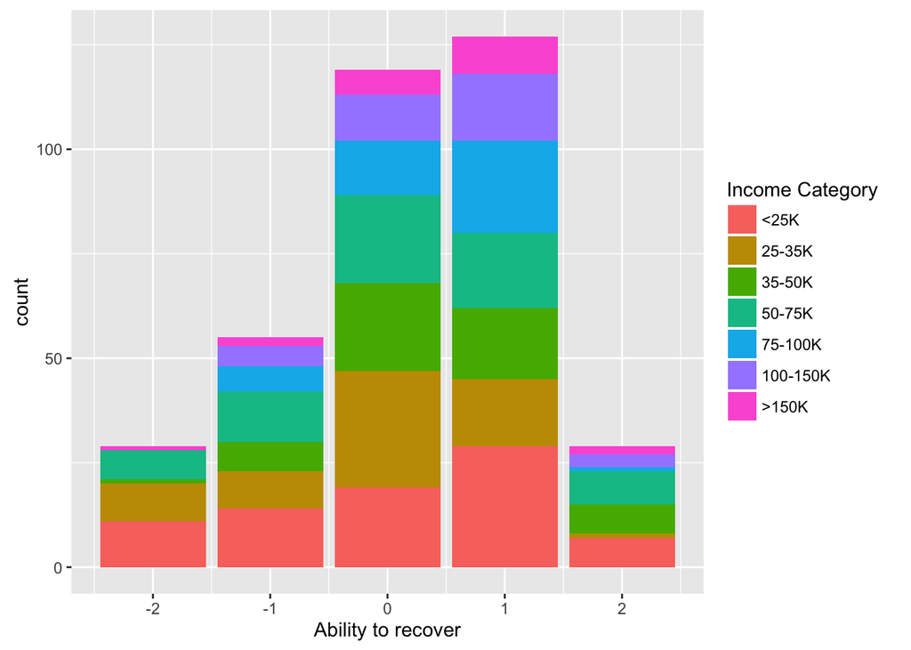

```r
  #by income
ggplot(sgeo, aes(PCNoRecov))+
  geom_bar(aes(fill = as.factor(Hincome))) +
  scale_fill_discrete(name = "Income Category", breaks = c(1:7),
                      labels = c("<25K","25-35K","35-50K","50-75K","75-100K","100-150K",">150K")) +
  labs(x = "Ability to recover")
```

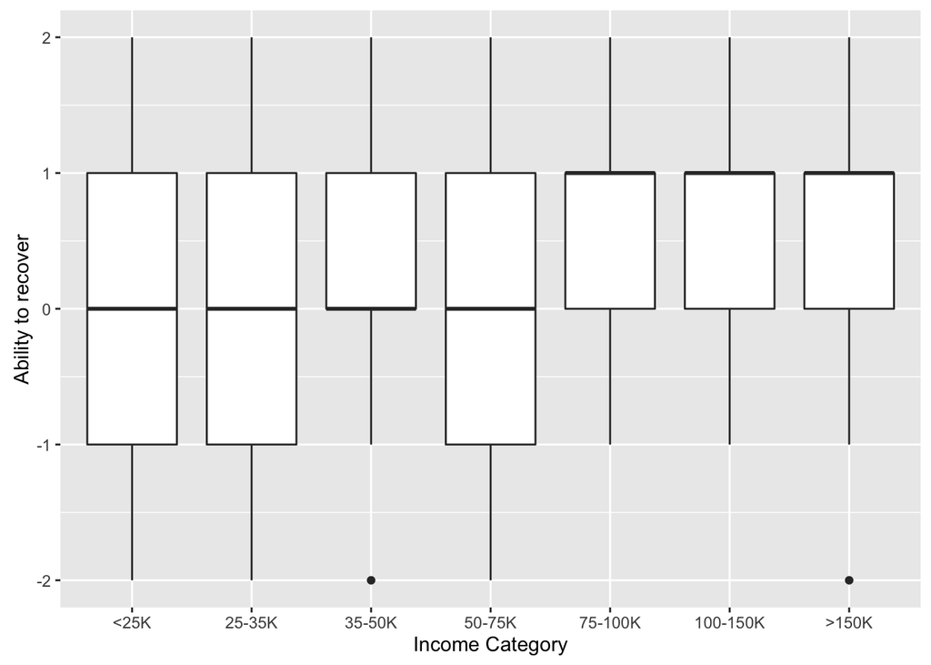

```r
a+
  geom_boxplot(mapping = aes(x = as.factor(Hincome), y = PCNoRecov))+
  scale_x_discrete(breaks = c(1:7),
                   labels = c("<25K","25-35K","35-50K","50-75K","75-100K","100-150K",">150K")) +
  labs(x = "Income Category", y = "Ability to recover")
```

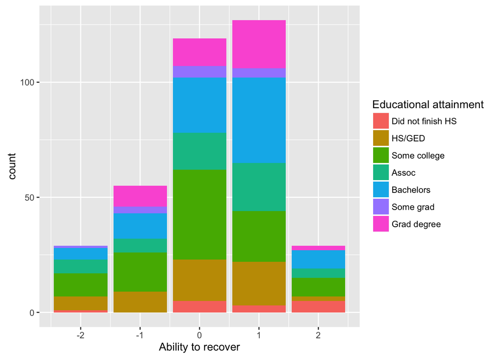

```r
  #by education
ggplot(sgeo, aes(PCNoRecov))+
  geom_bar(aes(fill = as.factor(Education))) +
  scale_fill_discrete(name = "Educational attainment", breaks = c(1:7),
                      labels = c("Did not finish HS","HS/GED","Some college","Assoc","Bachelors","Some grad","Grad degree")) +
  labs(x = "Ability to recover")
```

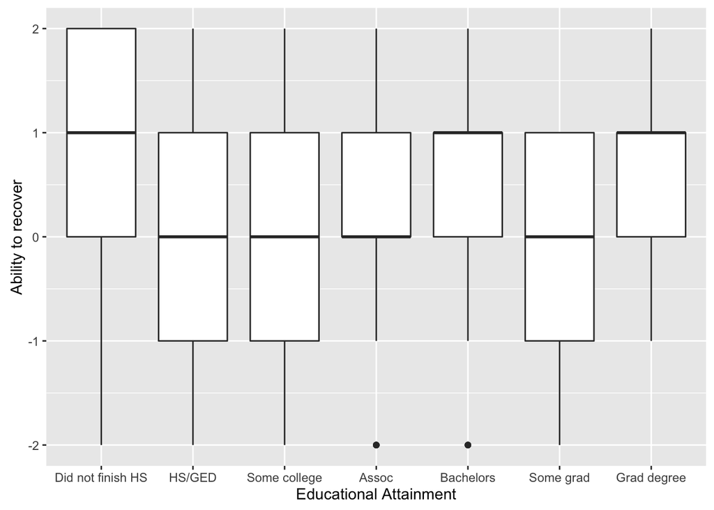

```r
a +
  geom_boxplot(mapping = aes(x = as.factor(Education),y = PCNoRecov)) +
  scale_x_discrete(breaks = c(1:7),
                   labels = c("Did not finish HS","HS/GED","Some college","Assoc","Bachelors","Some grad","Grad degree"))+
  labs(x = "Educational Attainment", y = "Ability to recover")
```

Whites and African Americans reported similar abilies to recovery, but the values for Hispanics were consistently lower. The other groups were simlar to White and African American, but these made up a very small proportion of the respondents, as noted above, so the results must be taken with some caution. Respondents with incomes above $75,000 reported greater ability to recover on average–this is not surprising. Education did not exhibit much variation; interestingly, however, respondents with less than a high school degree were more confident that they could recover from storm impacts.